# DIGI405 Lab Class 8: LLM Text classification

⚠️ **Run this notebook in Google Colab - not in the DIGI405 JupyterHub**. You will want to change to a GPU/TPU accelerated runtime. To do this go to Runtime > Change runtime type. Read more about GPU/TPU availability in Google Colab [here](https://research.google.com/colaboratory/faq.html#gpu-availability).

In this notebook we'll compare the performance of an LLM model, [Hugging Face DistilBERT base (uncased)](https://huggingface.co/distilbert-base-uncased), and a Bag of Words model, the [sci-kit learn multinomial Naive Bayes classifier](https://scikit-learn.org/stable/modules/generated/sklearn.naive_bayes.MultinomialNB.html) on the same dataset.

The first part of this notebook is exactly the same as our other lab notebook. Run through all the cells in the notebook to ensure all the data is loaded correctly, and the Naive Bayes model is trained for comparison. You may want to use the 'best' pre-processing and feature selection settings that you found for the Naive Bayes model.

In the second part of the notebook we'll fine-tune the ["distilbert-base-uncased"](https://huggingface.co/distilbert/distilbert-base-uncased) model on our dataset and compare its classification performance against the Naive Bayes model. DistilBERT base (uncased) is accessed through the 🤗 Hugging Face transformers library.

**Remember:** Each time you change settings below, you need to rerun the following cells in order to implement the classification pipeline.

## Setup

Below we are importing required libraries.

We will use the [Naive Bayes Classifier](https://scikit-learn.org/stable/modules/naive_bayes.html). We will also use Scikit-learn's different feature extraction methods based on counts or tf-idf weights. The [NLTK](https://www.nltk.org/) library is used for pre-processing.

```python
# Install datasets
!pip install datasets==2.14.5
```

[output not shown]

```python
from sklearn.datasets import load_files
from sklearn.model_selection import train_test_split
from sklearn import metrics
from sklearn.pipeline import Pipeline
from sklearn.naive_bayes import MultinomialNB
from sklearn.feature_extraction.text import CountVectorizer
from sklearn.feature_extraction.text import TfidfVectorizer
from sklearn.metrics import ConfusionMatrixDisplay
from sklearn.datasets import fetch_20newsgroups
from sklearn.metrics import classification_report

import numpy as np
import pandas as pd

import matplotlib.pyplot as plt
from wordcloud import WordCloud

import re
import warnings

import nltk
from nltk import word_tokenize
from nltk.tokenize import wordpunct_tokenize
from nltk.tokenize import RegexpTokenizer
from nltk.stem import WordNetLemmatizer
from nltk.stem import SnowballStemmer
from nltk.stem import PorterStemmer
from nltk.corpus import wordnet
```

The following step downloads the following [NLTK](https://www.nltk.org/) resources: stopwords, the POS tagger (used by the NLTK lemmatizer), the Punkt tokenizer models, and the [WordNet lexical database](https://wordnet.princeton.edu/) (used for word meanings and relationships).

```python
nltk.download('stopwords')
nltk.download('averaged_perceptron_tagger')
nltk.download('punkt')
nltk.download('wordnet')
```

```
True
```

This cell loads some defaults for the stop word lists.

```python
stop_words = None
from sklearn.feature_extraction.text import ENGLISH_STOP_WORDS as sklearn_stop_words
nltk_stop_words = nltk.corpus.stopwords.words('english')
```

Define some functions (you don't need to change anything here, just run the cell) ...

```python
# nice preview of document
def get_preview(docs, targets, target_names, doc_id, max_len=0):
    preview = ''
    if max_len < 1:
        preview += 'Label\n'
        preview += '=====\n'
    else:
        preview += str(doc_id)
        preview += '\t'
    preview += target_names[targets[doc_id]]
    if max_len < 1:
        preview += '\n\nFull Text\n'
        preview += '=========\n'
        preview += docs[doc_id]
        preview += '\n'
    else:
        excerpt = get_excerpt(docs[doc_id], max_len)
        preview += '\t' + excerpt
    return preview

_RE_COMBINE_WHITESPACE = re.compile(r"\s+")

# generate an excerpt
def get_excerpt(text, max_len):
    excerpt = _RE_COMBINE_WHITESPACE.sub(' ',text[0:max_len])
    if max_len < len(text):
        excerpt += '...'
    return excerpt.strip()

# combine a defined stop word list (or no stop word list) with any extra stop words defined
def set_stop_words(stop_word_list, extra_stop_words):
    if len(extra_stop_words) > 0:
        if stop_word_list is None:
            stop_word_list = []
        stop_words = list(stop_word_list) + extra_stop_words
    else:
        stop_words = stop_word_list

    return stop_words

# initiate stemming or lemmatising
def set_normaliser(normalise):
    if normalise == 'PorterStemmer':
        normaliser = PorterStemmer()
    elif normalise == 'SnowballStemmer':
        normaliser = SnowballStemmer('english')
    elif normalise == 'WordNetLemmatizer':
        normaliser = WordNetLemmatizer()
    else:
        normaliser = None
    return normaliser

# we are using a custom tokenisation process to allow different tokenisers and stemming/lemmatising ...
def tokenise(doc):
    global tokeniser, normalise, normaliser

    # you could obviously add more tokenisers here if you wanted ...
    if tokeniser == 'sklearn':
        tokenizer = RegexpTokenizer(r"(?u)\b\w\w+\b") # this is copied straight from sklearn source
        tokens = tokenizer.tokenize(doc)
    elif tokeniser == 'word_tokenize':
        tokens = word_tokenize(doc)
    elif tokeniser == 'wordpunct':
        tokens = wordpunct_tokenize(doc)
    else:
        tokens = word_tokenize(doc)

    # if using a normaliser then iterate through tokens and return the normalised tokens ...
    if normalise == 'PorterStemmer':
        return [normaliser.stem(t) for t in tokens]
    elif normalise == 'SnowballStemmer':
        return [normaliser.stem(t) for t in tokens]
    elif normalise == 'WordNetLemmatizer':
        # NLTK's lemmatiser needs parts of speech, otherwise assumes everything is a noun
        pos_tokens = nltk.pos_tag(tokens)
        lemmatised_tokens = []
        for token in pos_tokens:
            # NLTK's lemmatiser needs specific values for pos tags - this rewrites them ...
            # default to noun
            tag = wordnet.NOUN
            if token[1].startswith('J'):
                tag = wordnet.ADJ
            elif token[1].startswith('V'):
                tag = wordnet.VERB
            elif token[1].startswith('R'):
                tag = wordnet.ADV
            lemmatised_tokens.append(normaliser.lemmatize(token[0],tag))
        return lemmatised_tokens
    else:
        # no normaliser so just return tokens
        return tokens
```

## Preview stop word lists

As discussed in the lecture material, pre-processing can have a major influence on the results of text classification tasks.

In particular, you should put thought into whether a stop word list is sensible for your task. The scikit-learn website also makes this point at https://scikit-learn.org/stable/modules/feature_extraction.html#stop-words and recommends caution about using its stop word list! That page also links to a recent paper discussing practical issues with stop word lists, including whether the way you are tokenising your documents matches the tokenisation approach used in your stop word list.

Using the cells below you can preview the stop word lists supplied by scikit-learn and NLTK, which we have used previously in class. You will notice they are quite different.

```python
print(sklearn_stop_words)
```

```
frozenset({'move', 'from', 'seemed', 'at', 'over', 'less', 'beside', 'only', 'ever', 'such', 'another', 'un', 'thin', 'indeed', 'least', 'every', 'our', 'thereafter', 'rather', 'until', 'enough', 'within', 'otherwise', 'nine', 'beyond', 'what', 'top', 'through', 'yourselves', 'fire', 'but', 'hence',…
```

```python
print(nltk_stop_words)
```

```
['i', 'me', 'my', 'myself', 'we', 'our', 'ours', 'ourselves', 'you', "you're", "you've", "you'll", "you'd", 'your', 'yours', 'yourself', 'yourselves', 'he', 'him', 'his', 'himself', 'she', "she's", 'her', 'hers', 'herself', 'it', "it's", 'its', 'itself', 'they', 'them', 'their', 'theirs', 'themselve…
```

## Load corpus and set train/test split

Scikit-learn is packaged with a number of standard data-sets used in machine learning and provides a way to load other data.

We will begin by loading texts from two categories in the **[20 newsgroups dataset](http://qwone.com/~jason/20Newsgroups/)** to work through an example classifying documents related to politics and religion.

*What is a newsgroup?* We are stretching back into internet history here - way before people talked to strangers on Facebook and X and other social media, there were Usenet Newsgroups! [Here is a link to a Deja News page from 1998](https://web.archive.org/web/19980127204536/http://emarket.dejanews.com/emarket/about/idgs/aboutidgs.shtml) and also a [Wikipedia article](https://en.wikipedia.org/wiki/Usenet_newsgroup) that explains what Newsgroups are all about.

This data-set was built from discussions between real people on the internet in the 1990s. Please be aware that within this data-set are texts that include racist, sexist, and other offensive language use.

**Note:** This cell also sets the following train/test split: **80% of the data is used for training and 20% is used for testing.** The documents are assigned to each group randomly. It can be useful to rerun this cell to reshuffle your dataset so you can evaluate your model using different data for training and testing.

```python
# this chooses the categories to load
cats = ['talk.politics.misc', 'talk.religion.misc']

# this downloads/loads the data
# dataset = fetch_20newsgroups(subset='train', categories=cats)
dataset = fetch_20newsgroups(subset='train', remove=('headers', 'footers', 'quotes'), categories=cats)

# assign the train/test split - 0.2 is 80% for training, 20% for testing
test_size = 0.2

# do the train test split ...
# docs_train and docs_test are the documents
# y_train and y_test are the labels
docs_train, docs_test, y_train, y_test = train_test_split(dataset.data, dataset.target,
                                                          test_size = test_size, random_state=None)
```

## Inspect documents and labels

In the next cells we can look at the data we have imported. Firstly, we will preview the document labels and a brief excerpt.

```python
for train_id in range(len(docs_train)):
    print(get_preview(docs_train, y_train, dataset.target_names, train_id, max_len=80))
```

```
0	talk.politics.misc	#Tells you something about the fascist politics being practiced .... Ah, ending...
1	talk.religion.misc
2	talk.religion.misc	/(emery) /The one single historic event that has had the biggest impact on the /...
3	talk.politics.misc	You need to hop over to talk.politics.misc. Wee have been chewing on this ge...
4	talk.politics.misc	Some survey conducted by the U.S. government and some group (I don't know whic...
5	talk.politics.misc	So which are you advocating? That You know Nothing About American History, Or...
6	talk.religion.misc	Sorry, but it doesn't matter what _you_ think, I am a Christian, who happens to...
7	talk.politics.misc	Some people pay shares that are more "fair" than others, and will continue to d...
8	talk.politics.misc	Turkish president Turgur Ozal has passed away today after a heart attack in Ank...
9	talk.politics.misc	Replying to A.J. Teel: Well, the two nifty letters giving concrete proof that ...
10	talk.religion.misc	That is because two creation stories is one of the worst examples of a diffic...
11	talk.religion.misc	On 15 Apr 1993 22:34:40 GMT, Eric Sieferman observed: : Christian: washed in t...
12	talk.politics.misc	I'll answer you're sarcasm with more sarcasm: Boy, it looks like the WOD is W...
13	talk.religion.misc	COCHRANE,JAMES SHAPLEIGH writes This group killed itself to fulfill its interp...
14	talk.politics.misc	You're right, I bailed out in Diff Eq. Nevertheless, I would sugge...
15	talk.religion.misc	I happen to take the violation of a person much more seriously than the "violat...
16	talk.religion.misc	......@compuserve.com
17	talk.religion.misc	Not to be too snide about it, but I think this Christianity must be a very co...
18	talk.politics.misc	kaldis@romulus.rutgers.edu (Theodore A. Kaldis) writes... Actually, my ...
19	talk.politics.misc	[stuff deleted] Then why not simply stop reading them. This isn't intended as...
20	talk.religion.misc	-*---- The two commandments *are* rules; they are merely rules that are so vagu...
21	talk.religion.misc	There are actually a few important things we can glean from this mess: 1) When t...
22	talk.politics.misc
23	talk.politics.misc	I totally agree. Really, the only people this is going to benefit, are those w...
24	talk.politics.misc	I followed up without a thought of double-checking...if I double-checked every...
25	talk.politics.misc	Wasn't it Tricky Dick who issued stern warnings to Bush & Clinton not to 'Lose ...
26	talk.politics.misc	If a six year old child does a funny trick and you say well done he will do it...
27	talk.religion.misc	PSA 145:9 The LORD is good to all: and his tender mercies are over all his w...
28	talk.politics.misc	*Paranoia part deleted.*
29	talk.politics.misc	#Compared to the table I have already posted from Masters, Johnson, #and Kolodny...
30	talk.religion.misc	And organized religion is a religion built from organized values. And Ford Te...
31	talk.politics.misc	##It should be noted that NAMBLA has not been present in the ##other 600 or so ...
32	talk.religion.misc	Well, that would depend on how much we wanted the US and how much we wanted the ...
33	talk.religion.misc	Sorry, but Mormons aren't generally considered to be Christians.
34	talk.politics.misc	This is a difficult problem for which there is no obviously good solution. On...
35	talk.religion.misc	You keep saying that. I do not think it means what you think it means. Perhaps y...
36	talk.religion.misc	Is it not the case that, in the eyes of the law, when someone is aware of someth...
37	talk.religion.misc	Well, when you crosspost to talk.origins, what do you expect?
38	talk.religion.misc	Where were you brought up? In the former USSR? Is Innocent until proven gui...
39	talk.religion.misc	I would really appreciate if when someone brought something like this up t...
```

[output cut: 618 more lines]

```
658	talk.religion.misc	In two places at once? Bit of a coincidence, that. Whatever the faults the FB...
659	talk.politics.misc
660	talk.politics.misc	Not true. I am required to have insurance by law. the method of collection eff...
661	talk.politics.misc	Top Ten Ways Slick Willie Could Improve His Standing With Americans 10. Insti...
662	talk.politics.misc	# #From the Santa Rosa (Cal.) Press-Democrat, April 15, 1993, p. B2: # # # # ...
663	talk.politics.misc	# # Unfortunately, homosexuals don't believe in this concept of freedom. # # The...
664	talk.religion.misc	Actually, jon, that is quite true. Christian people have caused "objective mor...
665	talk.politics.misc	I don't believe in the "Wave Theory". My mother-in-law, who grew up in Germ...
666	talk.politics.misc	In regard to Woody's post, I thought I would remind him of something in the mids...
667	talk.politics.misc	Ed: Before you ridicule the intelligence of other people, LEARN TO SPELL...
668	talk.politics.misc	Could it be because you're British, Phill, and living in Germany? While the EC ...
669	talk.politics.misc	Oh, you foolish person. I do know what the fuck I'm talking about and will gl...
670	talk.religion.misc	<Moral Driver distinctions deleted> Compare the Driver to an urge such as Jea...
671	talk.politics.misc	THE WHITE HOUSE Office of the Press Secretary _____________...
672	talk.religion.misc	My online Bible is on a CD, but I don't own a CD-ROM system for the time being,...
```

### You can use the following cell to inspect a specific document and its label based on its index in the training set.

Note: The indexes will change each time you import the data above because of the random train/test split.

```python
train_id = 1  # Enter the index of the document you want to preview
print(get_preview(docs_train, y_train, dataset.target_names, train_id))
```

```
Label
=====
talk.religion.misc

Full Text
=========
```

## Preprocessing

**This next section of the notebook steps you through some key kinds of pre-processing for text classification using Naive Bayes and a bag of words (BoW) model.**

On the first run you should read about each setting, but leave the settings as they are. You will come back to this section to tune your model.

### Choose between token counts or tf-idf weights

You can choose to vectorize your text using frequency or tf-idf weights. Valid values are:

```
Vectorizer = CountVectorizer
```

or

```
Vectorizer = TfidfVectorizer
```

```python
Vectorizer = CountVectorizer  # Set the vectorization method you want to use
```

### Lowercase

Setting lowercase to True will transform all document text to lowercase. Setting it to False will not do this transformation.

```python
lowercase = True
```

### Set how you are tokenising the text

With this notebook you can choose between the following tokenisers.

This option duplicates the behaviour of scikit-learn's default tokeniser: "The default regexp select tokens of 2 or more alphanumeric characters (punctuation is completely ignored and always treated as a token separator)". In this notebook we duplicate this behaviour using the NLTK's regular expression tokeniser and this regular expression: `r"(?u)\b\w\w+\b"`.

```
tokeniser = 'sklearn'
```

You can use this or specify one of the following tokenisers based on NLTK ...

Tokenise based on NLTK's wordpunct_tokenize tokeniser (to include words and punctuation!):

```
tokeniser = 'wordpunct'
```

This applies NLTK's word_tokenize tokeniser.

```
tokeniser = 'word_tokenize'
```

```python
tokeniser = 'sklearn'
```

### Stemming / Lemmatising

This allows to use NLTK stemmers or lemmatisers (or not). Valid options are shown below. Look for more information on the NLTK website: https://www.nltk.org/api/nltk.stem.html. Note: that stemming and lemmatising (in particular) will make the preprocessing take longer!

```
normalise = None
```

or

```
normalise = 'PorterStemmer'
```

or

```
normalise = 'SnowballStemmer'
```

or

```
normalise = 'WordNetLemmatizer'
```

```python
normalise = None
```

### Configure stop words

Hopefully you have read the notes on stop word lists above and previewed the different lists.

Do you want to apply a stop_word list? Valid values for stop_words below are:

```
stop_word_list = None
```

or

```
stop_word_list = nltk_stop_words
```

or

```
stop_word_list = list(sklearn_stop_words)
```

**Note:** the sklearn_stop_words list is downloaded as a set. We use list() to convert it to a list type.

```python
stop_word_list = None
```

```python
print(stop_word_list)
```

```
None
```

You can also add extra stop words to any of the lists above. For example:

```
extra_stop_words = ['stopword1','stopword2','stopword3']
```

If you don't want extra stop words, then the next cell should look like:

```
extra_stop_words = []
```

```python
extra_stop_words = []
```

### Filter features based on document frequency

The following settings allow you to remove features that occur in many documents or in only a few documents.

Firstly, `min_df` ignores terms that occur below a minimum proportion of documents. For example, 0.01 would ignore terms that occur in less than 1% of documents.

```python
min_df = 0.0
```

`max_df` allows you to ignore terms above a maximum proportion of documents. For example, 0.95 would ignore terms that occur in more than 95% of documents.

```python
max_df = 1.0
```

### Set a maximum number of features

`max_features` set this to `None` for no limit or set to the maximum number of the most frequent features (e.g setting it to 1000 would use the 1000 most frequent features).

```python
max_features = 1000
```

### Ngrams

With ngram_range set to (1,1) you will use unigrams as features i.e. each feature will be a token. If you set it to (1,2) you will use unigrams and bigrams. (1,3) will use unigrams, bigrams and trigrams. If you just want bigrams you would use (2,2). Please note: increasing the ngram range from (1,1) will add more time to preprocessing, as there will be more features.

```python
ngram_range = (1,1)
```

### Encoding options

You can change the default encoding here and what to do if you get characters outside your default encoding.

```python
encoding = 'utf-8'
decode_error = 'ignore' # what to do if contains characters not of the given encoding - options 'strict', 'ignore', 'replace'
```

## Setup the feature extraction and classification pipeline

This sets up a Sci-kit learn pipeline for feature extraction and classification.

**Important Note 1:** When you change settings above or reload your dataset you should rerun this cell!

**Important Note 2:** This cell outputs the settings you used above, which you can cut and paste into a document to keep track of changes you are making and their effects.

```python
# you shouldn't need to change anything in this cell!

stop_words = set_stop_words(stop_word_list, extra_stop_words)
normaliser = set_normaliser(normalise)

pipeline = Pipeline([
    ('vectorizer', Vectorizer(
            tokenizer = tokenise,
            lowercase = lowercase,
            min_df = min_df,
            max_df = max_df,
            max_features = max_features,
            stop_words = stop_words,
            ngram_range = ngram_range,
            encoding = encoding,
            decode_error = decode_error)),
    ('classifier', MultinomialNB()), #here is where you would specify an alternative classifier
])

print('Classifier settings')
print('===================')
print('classifier:', type(pipeline.steps[1][1]).__name__)
print('vectorizer:', type(pipeline.steps[0][1]).__name__)
print('classes:', dataset.target_names)
print('lowercase:', lowercase)
print('tokeniser:', tokeniser)
print('normalise:', normalise)
print('min_df:', min_df)
print('max_df:', max_df)
print('max_features:', max_features)
if stop_word_list == nltk_stop_words:
    print('stop_word_list:', 'nltk_stop_words')
elif stop_word_list == list(sklearn_stop_words):
    print('stop_word_list:', 'sklearn_stop_words')
else:
    print('stop_word_list:', 'None')
print('extra_stop_words:', extra_stop_words)
print('ngram_range:', ngram_range)
print('encoding:', encoding)
print('decode_error:', decode_error)
```

```
Classifier settings
===================
classifier: MultinomialNB
vectorizer: CountVectorizer
classes: ['talk.politics.misc', 'talk.religion.misc']
lowercase: True
tokeniser: sklearn
normalise: None
min_df: 0.0
max_df: 1.0
max_features: 1000
stop_word_list: None
extra_stop_words: []
ngram_range: (1, 1)
encoding: utf-8
decode_error: ignore
```

## Train the classifier and predict labels on test data

This cell does the work of training the classifier and predicting labels on test data. It also outputs evaluation metrics, a confusion matrix and features indicative of each class.

**Important Note:** You can cut and paste the model output into a document (with the settings above) to keep track of changes you are making and their effects.

```
Evaluation metrics
==================

                    precision    recall  f1-score   support

talk.politics.misc       0.87      0.71      0.78        93
talk.religion.misc       0.71      0.87      0.78        76

          accuracy                           0.78       169
         macro avg       0.79      0.79      0.78       169
      weighted avg       0.80      0.78      0.78       169
```

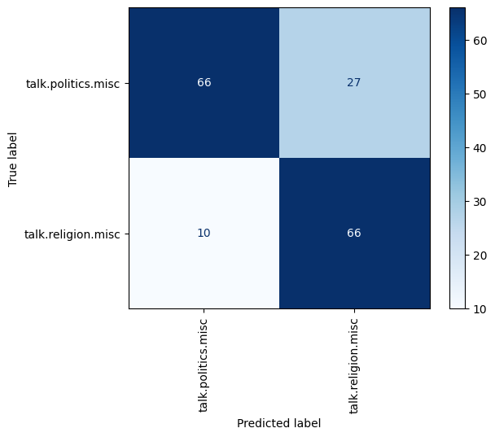

```
Features most indicative of talk.politics.misc
==============================================
stephanopoulos myers package administration president jobs summer billion funds vat rockefeller naval budget russia drugs george congress stimulus island labor

Features most indicative of talk.religion.misc
==============================================
jesus bible christians judas jim lds christian tyre christ hudson koresh christianity biblical decenso mormon weiss db ra kent testament
```

```python
# you shouldn't need to change anything in this cell!
warnings.filterwarnings("ignore", category=UserWarning)

pipeline.fit(docs_train, y_train)
y_predicted = pipeline.predict(docs_test)

# print report
print('\nEvaluation metrics')
print('==================\n')
print(metrics.classification_report(y_test, y_predicted, target_names = dataset.target_names))
cm = metrics.confusion_matrix(y_true=y_test, y_pred=y_predicted, labels=[0, 1])

disp = ConfusionMatrixDisplay(confusion_matrix=cm, display_labels=dataset.target_names)
disp = disp.plot(include_values=True, cmap='Blues', ax=None, xticks_rotation='vertical')
plt.show()

vect = pipeline.steps[0][1]
clf = pipeline.steps[1][1]

print()

logodds=clf.feature_log_prob_[1]-clf.feature_log_prob_[0]

print("Features most indicative of",dataset.target_names[0])
print('============================' + '='*len(dataset.target_names[0]))
for i in np.argsort(logodds)[:20]:
    print(vect.get_feature_names_out()[i], end=' ')
print()
print()

print("Features most indicative of",dataset.target_names[1])
print('============================' + '='*len(dataset.target_names[1]))
for i in np.argsort(-logodds)[:20]:
    print(vect.get_feature_names_out()[i], end=' ')

lookup = dict((v,k) for k,v in vect.vocabulary_.items())
```

## List all features

Just for your reference here is a count and list of all features used in this model.

```python
print('Total Features: ',len(vect.get_feature_names_out()))
print(vect.get_feature_names_out())
```

```
Total Features:  1000
['000' '10' '100' '11' '12' '13' '14' '15' '16' '17' '18' '19' '1993' '20'
 '25' '30' '40' 'able' 'about' 'above' 'absolutely' 'accept' 'according'
 'account' 'act' 'action' 'actions' 'acts' 'actually' 'add' 'address'
 'administration' 'admit' 'african' 'after' 'again' 'against' 'ago'
 'agree' 'agreed' 'aid' 'all' 'allah' 'allowed' 'almost' 'alone' 'along'
 'already' 'also' 'although' 'always' 'am' 'america' 'american'
 'americans' 'among' 'amount' 'an' 'and' 'angeles' 'another' 'answer'
 'answers' 'anti' 'any' 'anyone' 'anything' 'anyway' 'apply' 'approach'
 'april' 'are' 'area' 'areas' 'aren' 'argentina' 'argentine' 'argument'
 'arguments' 'around' 'article' 'articles' 'as' 'ask' 'asked' 'assistance'
 'assume' 'at' 'atlantic' 'attack' 'authority' 'available' 'aware' 'away'
 'back' 'bad' 'base' 'based' 'basic' 'basis' 'be' 'because' 'become'
 'been' 'before' 'behind' 'being' 'belief' 'beliefs' 'believe' 'benefits'
 'best' 'better' 'between' 'beyond' 'bible' 'biblical' 'big' 'bill'
 'billion' 'bit' 'black' 'blacks' 'blood' 'body' 'bolshevik' 'book'
 'books' 'bosnia' 'both' 'break' 'briefing' 'bring' 'british' 'btw'
 'budget' 'build' 'building' 'built' 'bush' 'business' 'but' 'by' 'call'
 'called' 'came' 'can' 'canada' 'cannot' 'care' 'carry' 'case' 'cases'
 'cause' 'certain' 'certainly' 'chance' 'change' 'changed' 'child'
 'children' 'choice' 'choose' 'christ' 'christian' 'christianity'
 'christians' 'church' 'cities' 'city' 'civil' 'claim' 'claims' 'class'
 'clear' 'clearly' 'clinton' 'code' 'college' 'colorado' 'com' 'come'
 'comes' 'coming' 'comment' 'comments' 'commitment' 'common' 'community'
 'complete' 'concept' 'conclusion' 'congress' 'consider' 'consideration'
 'considered' 'considering' 'constitution' 'context' 'continue' 'control'
 'correct' 'cost' 'costs' 'could' 'countries' 'country' 'couple' 'course'
 'court' 'create' 'created' 'creation' 'crime' 'crimes' 'cs' 'cultural'
 'culture' 'current' 'cut' 'data' 'david' 'day' 'days' 'db' 'dead' 'deal'
 'death' 'decenso' 'decide' 'decided' 'decision' 'decisions' 'dee'
 'defense' 'deficit' 'definition' 'deleted' 'democracy' 'democratic'
 'department' 'details' 'development' 'did' 'didn' 'died' 'difference'
 'different' 'difficult' 'directly' 'discuss' 'discussed' 'discussion'
 'do' 'doctrine' 'does' 'doesn' 'doing' 'dole' 'dollars' 'don' 'done'
 'doubt' 'down' 'drug' 'drugs' 'due' 'during' 'each' 'earlier' 'early'
 'earth' 'economic' 'economy' 'edu' 'education' 'effect' 'effort'
 'efforts' 'either' 'else' 'end' 'energy' 'english' 'enough' 'entire'
 'especially' 'etc' 'even' 'ever' 'every' 'everyone' 'everything'
 'evidence' 'evil' 'exactly' 'example' 'except' 'exist' 'existence'
 'expect' 'experience' 'explain' 'extra' 'face' 'fact' 'fair' 'faith'
```

[output cut: 70 more lines]

```
 'things' 'think' 'thinking' 'this' 'those' 'though' 'thought' 'thousands'
 'threat' 'three' 'through' 'thus' 'time' 'times' 'to' 'today' 'together'
 'told' 'tomorrow' 'too' 'took' 'top' 'total' 'toward' 'trade' 'trial'
 'tried' 'trouble' 'true' 'truth' 'try' 'trying' 'turn' 'two' 'tyre'
 'under' 'understand' 'understanding' 'united' 'university' 'unless'
 'until' 'up' 'upon' 'us' 'usa' 'use' 'used' 'using' 'usually' 'value'
 'values' 'various' 'vat' 've' 'very' 'view' 'views' 'vote' 'want'
 'wanted' 'wants' 'war' 'was' 'washington' 'wasn' 'water' 'way' 'ways'
 'we' 'weapons' 'week' 'weeks' 'weiss' 'well' 'went' 'were' 'western'
 'what' 'whatever' 'when' 'where' 'whether' 'which' 'while' 'white' 'who'
 'whole' 'whom' 'whose' 'why' 'wide' 'will' 'willing' 'wish' 'with'
 'within' 'without' 'won' 'wonder' 'word' 'words' 'work' 'working' 'works'
 'world' 'worth' 'would' 'wouldn' 'writes' 'written' 'wrong' 'wrote'
 'year' 'years' 'yes' 'yesterday' 'yet' 'york' 'you' 'young' 'your'
 'yourself']
```

## Inspect correctly/incorrectly classified documents

The output in the next cell is quite long and will take a few moments to generate. It will show you wordclouds and a preview of documents for correctly and incorrectly classified documents. The size of words in the wordclouds are based on adding up counts/tf-idf scores of features based on documents related to each cell in the confusion matrix

```
CORRECTLY CLASSIFIED:
talk.politics.misc
=================================================================
```

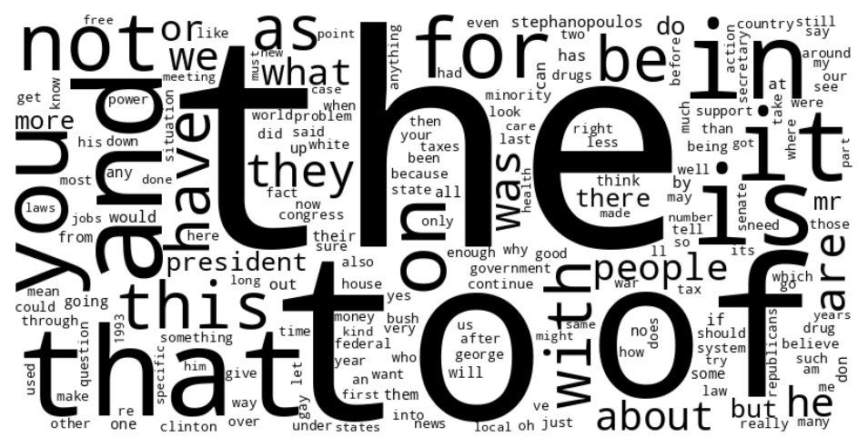

```
0	talk.politics.misc	--------------------------- The federal government has used such laws to allow m...
1	talk.politics.misc	You have just reminded me of an old Tom Paxton song... I"M CHANGING MY NAME TO...
2	talk.politics.misc	Ahhh, the classic Truth By Blatant Assertion technique. Too bad it's so demons...
3	talk.politics.misc	Well yes and no. The Federalist papers are propaganda and it is therefore diff...
4	talk.politics.misc	: >The Selective Service Registration should be abolished. To start with, the :...
8	talk.politics.misc	Pardon me for interrupting, but why doesn't anyone ever bring up other possibili...
9	talk.politics.misc	Also, it appears that two of the three Marines have some sort of charges pending...
10	talk.politics.misc	From article <C4zLJ8.Bun@queernet.org>, by rogerk@queernet.org (Roger B.A. Klore...
12	talk.politics.misc	You don't have to. *It* believes in YOU. Well, look...
14	talk.politics.misc	# # "Abortions destructive of the fetus must be permitted, even # # just befo...
18	talk.politics.misc	You asked a question, and now you don't want people to answer? I believe a leg...
23	talk.politics.misc	"Women are only interested in clothes and shopping" "Whites are imperial...
24	talk.politics.misc	Judging from past experience (the '87 March, a Peace and Justice March the sa...
32	talk.politics.misc	Only the most comprehensive survey on sexuality in 50 years. Chance and size ...
34	talk.politics.misc	No, it's a sign of aristocrtic out-of-touchness with the middle class. You ask...
36	talk.politics.misc	# ## Face it, Clayton, he was not found guilty, and so what if gays sometimes # ...
37	talk.politics.misc	s, This country is hardly ruined. In fact, it is booming compared to after the...
38	talk.politics.misc	[...] You seem to be saying that a LIMITED government will provide MORE oppor...
43	talk.politics.misc	Last night I heard something about Bill Clinton's sister being involved in a mar...
45	talk.politics.misc	I'm sorry about your friend. Really. But this anecdote does nothing to justif...
48	talk.politics.misc	What evidence are you aware of. What was reported in the media, or all of the ...
50	talk.politics.misc	THE WHITE HOUSE Office of the Press Secretary ____________...
59	talk.politics.misc	Alan, you can start by teaching your children that the perpetrators of cr...
64	talk.politics.misc	You said it worked so well with tobacco. I was being fascisious(I can't spell ...
66	talk.politics.misc	Agreed. We need more folks to admit they're bi. -- Michael D. Adams (starow...
69	talk.politics.misc	# #Unfortunately, homosexuals don't believe in this concept of freedom. # #They ...
70	talk.politics.misc	In case you haven't noticed, Clintonites are pushing a universal health ...
73	talk.politics.misc	WOW !!!! Did I discover a great BBS !! It's called Sovereignty Lies In The Peopl...
74	talk.politics.misc	Horrors, appealing to popular principles. Can we perhaps as the questio...
75	talk.politics.misc	I did hear this question asked during a radio news update of the case. (They we...
76	talk.politics.misc	My opinion is this: In a society whose economy is primarily based on capitali...
79	talk.politics.misc	Chapter 7 operation in Somlia. Almost Chapter 7 in Cambodia and Yugo. '...
88	talk.politics.misc	Hi, Wonder how much money is being spent at Waco by BATF ? Are we paying beca...
89	talk.politics.misc	The DEA and other organizations would have the American people believe that we a...
90	talk.politics.misc	In <1993Apr15.045651.6892@midway.uchicago.edu>, thf2@midway.uchicago.edu sez: E...
92	talk.politics.misc	Didn't the new study asked "have you engaged in homosexual intercourse within th...
93	talk.politics.misc	william@fractl.tn.cornell.edu said in response to Dave Borden: William: If the...
100	talk.politics.misc	Here's my own top ten response to Mr. Ipser's list 10. It's about time we h...
104	talk.politics.misc	I guess your strength isn't in math. Clinton hasn't been president for 6 months...
106	talk.politics.misc	Possibly because gay/bi men are less likely to get married? What was the pur...
```

[output cut: 15 more lines]

```
141	talk.politics.misc	Yes, sadly, this is true. The primary reason, and the essence of the details th...
143	talk.politics.misc	-> : According to a ``CNN Poll'' to key reason for Clinton's low -> : approval ...
149	talk.politics.misc	_TOO_ many.
150	talk.politics.misc	And not only that, made a second clone from the same tissue sample after that ...
151	talk.politics.misc	[Patrick's example of anti-competitive regulations for auto de...
153	talk.politics.misc	Just observed at the National Model United Nations here in NYC. Just one...
155	talk.politics.misc	I was a graduate student in the early 1980s, and we had a conference on Reagano...
157	talk.politics.misc	I notice you did not offer an alternative number. Try this one on for size......
158	talk.politics.misc	You misunderstand. I'm not trying to prove a *cause* for anything. Merely po...
160	talk.politics.misc	improve these kids' chances>>of getting another job in the future, but what inn...
165	talk.politics.misc	There are a couple of ways to look at them. One is, "We want you to sup...


talk.politics.misc INCORRECTLY CLASSIFIED as: talk.religion.misc
=================================================================
```

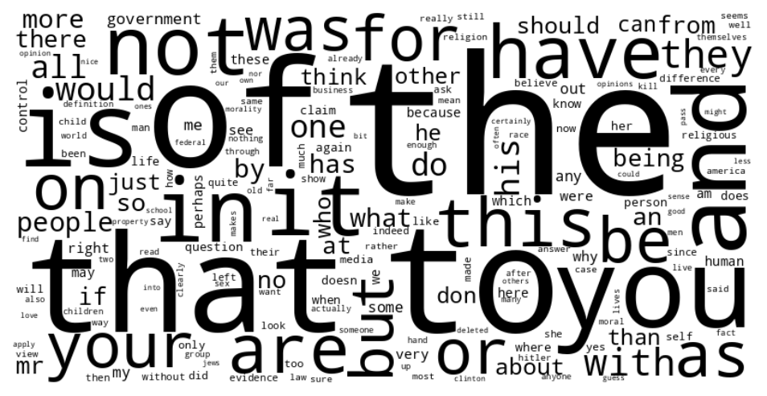

```
5	talk.politics.misc	Who wants to look through the bars at some reactionary Liberal conspiracy- theor...
15	talk.politics.misc	Nice dodge. I give it a 9.2. Now to answer your questions. I do not beli...
22	talk.politics.misc	I have to agree with you... the police may have carried it a bit too far but R...
26	talk.politics.misc	Perhaps 1%, but most likely not more than 2%. A new study (discrediting Kinsey)...
27	talk.politics.misc	The fact that she was wearing a miniskirt with no underwear was presented as...
30	talk.politics.misc	I don't know about everybody else, but to me, they should have been convicted B...
42	talk.politics.misc	And the religious right worships engines, smokestacks, landfills, and hates peo...
51	talk.politics.misc	The key word is `spilled'. If semen was spilled anywhere where there was a cha...
54	talk.politics.misc	Not at a...
60	talk.politics.misc	And the reason that the Soviet Union couldn't achieve the ideal of pure communi...
61	talk.politics.misc	In the case of victimless crimes yes, I think so. Think about it. If I rob or...
62	talk.politics.misc	Yes, and of course the Kinsey Report taken 50 years ago in much more liberal t...
67	talk.politics.misc	Not quite. The answer is: Many homosexuals, heterosexual, and bisexuals are,...
82	talk.politics.misc	Evidence given for her prostitute status, besides the admittedly questionable ...
87	talk.politics.misc	Cite one of these conflicting statutes. You keep making these assertions, but ...
98	talk.politics.misc	>It is very difficult for a young person to develop and build >a positiv...
99	talk.politics.misc	This meaningless statement makes YOU look bad.
102	talk.politics.misc	Why all the quote marks, Roy? I can see that they might be appropriate where t...
105	talk.politics.misc	#That describes some straights -- and nearly all homosexual males. Can you prov...
110	talk.politics.misc	tes: . s. Or mug me. Why must you pursue this fantasy that all crime is derive...
123	talk.politics.misc	Once more around the racetrack. See the original statement that it is nonse...
133	talk.politics.misc	To answer your irrelevant question, yes a person of color is human, but I still...
137	talk.politics.misc	Which provided the basis for the denoument of the film which introduced Erro...
139	talk.politics.misc	This is as bad as the "Did You Know" Japan bashing of 2 weeks ago. After findi...
147	talk.politics.misc	But remember that had God extinguished the blasphemous trash of Europe (and Imp...
159	talk.politics.misc	Isn't is funny how someone who seems to know nothing about homosexuality uses ...
163	talk.politics.misc	[deleted for a very good reason which I'm sure you can guess] 0. Enact a law th...


talk.religion.misc INCORRECTLY CLASSIFIED as: talk.politics.misc
=================================================================
```

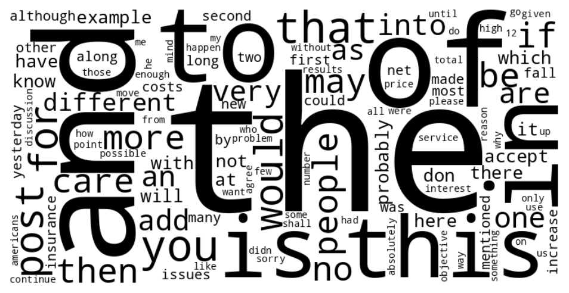

```
6	talk.religion.misc	->I addressed most of the key issues in this very long (284 lines) post ->by De...
17	talk.religion.misc	As many people have mentioned, there is no reason why insurers could not offer ...
35	talk.religion.misc
49	talk.religion.misc	Please do! And if you don't want to post it here, email to me :-) I don't know...
65	talk.religion.misc	Ps.92:12: "The righteous shall flourish like the palm tree."
68	talk.religion.misc	Absolutely. Lewis didn't care for the 1921 O.T.O. charter from Reuss. He had i...
77	talk.religion.misc	ONLY if you weight Americans equal to SAlvadorans.
83	talk.religion.misc	I will instruct thee and teach thee in the way which thou shalt go: I will gui...
122	talk.religion.misc	That happens to be a subjective example that the people of the US would happe...
162	talk.religion.misc


CORRECTLY CLASSIFIED:
talk.religion.misc
=================================================================
```

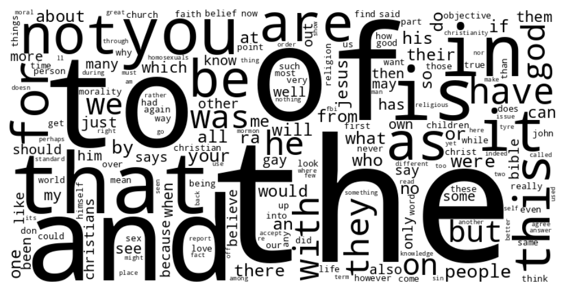

```
7	talk.religion.misc	I noticed this dead horse in your Keywords line. Is this the famous scarlet hor...
11	talk.religion.misc	Just a few cheap shots a Christianity: Riddle: What is the shortest street in J...
13	talk.religion.misc	IMO, a Christian has no need of weapons. I know it is very contrary to the Ame...
16	talk.religion.misc	What are the consequences of the homophobic ranting of the self-righteous? Well...
19	talk.religion.misc	You know, everybody scoffed at that guy they hung up on a cross too. He claime...
20	talk.religion.misc	There were many injustices in the middle ages. And this is truely sad. I woul...
21	talk.religion.misc	Dear Rob, Sometimes I do come across condesending, and I am sorry I come acros...
25	talk.religion.misc	And I maintain: Some people do not want to enter into the light and the knowle...
28	talk.religion.misc	These laws written for the Israelites, God's chosen people whom God had express...
29	talk.religion.misc	There has been a lot of discussion about Tyre. In sum, Ezekiel prophesied that ...
31	talk.religion.misc	Tony- While I honestly believe you believe you are doing a "good thing" by post...
33	talk.religion.misc	}>}So stop dodging the question. What is hypocritical about my }>}criticizing b...
39	talk.religion.misc	DM> Fact or rumor....? Madalyn Murray O'Hare an atheist who eliminated the DM> ...
40	talk.religion.misc	A lot of people won't agree with me. That's their right and I respect that. Ho...
41	talk.religion.misc	Dennis, I'm astounded. I didn't know you were interested to even study such fil...
44	talk.religion.misc	No, and Im especially unhappy that these 70+ people died in an assault on priva...
46	talk.religion.misc	DROPLET VOL 1, No 11, Part 3 D R O P L E T From The Vast Ocean Of The Miraculou...
47	talk.religion.misc	Make that 20%. Where did I see that poll recently about the very religious an...
52	talk.religion.misc	If anyone is interested in the history of AMORC, I do think Spencer Lewis publi...
53	talk.religion.misc	I'm not sure what you mean by 'saving face' unless you are confusing the FBI...
55	talk.religion.misc	Yes, that's true, but you have to be clear exactly what is an uninterpreted obse...
56	talk.religion.misc	How do you know? Were you there? While obviously Koresh was a nut case, the (...
57	talk.religion.misc	The problem is, your use of the word "objective" along with "values." Both ...
58	talk.religion.misc	There are actually a few important things we can glean from this mess: 1) When t...
63	talk.religion.misc	Your last remark is a contradiction, but I'll let that pass. I was addressing ...
71	talk.religion.misc	The same way that any theory is proven false. You examine the predicitions tha...
72	talk.religion.misc	Well, if they were Satanists, or followers of an obscure religion, then I would...
78	talk.religion.misc	There were some recent developments in the dispute about Masonry among Southern ...
80	talk.religion.misc	Women who are known not to want abortion services, for example, might be judged...
81	talk.religion.misc	I'm sorry, I thought we were discussing heresy. I assumed that heresy meant...
84	talk.religion.misc	[horror story about FBI ruining a guy's life for the hell of it omitted] So, ...
85	talk.religion.misc	perhaps you can quote just a bit of her argument?
86	talk.religion.misc	II SAMUEL 24: And again the anger of the LORD was kindled against Israel, and he...
91	talk.religion.misc	Let's see, if Alexander destroyed Tyre, and people move back, and they construc...
94	talk.religion.misc	Almost one third of the world's population claim to be Christian. But any sim...
95	talk.religion.misc	Nor, to point out the obvious, are the deluded, siege-mentality followers of a ...
96	talk.religion.misc	If given a definite definition of "God", it is sometimes possible to falsify...
97	talk.religion.misc	Good question. I don't have a nice concise answer, though. What about the chi...
101	talk.religion.misc	Those things, which ye have both learned, and received, and heard, and seen in...
103	talk.religion.misc	[deleted] The person who was telling me about the Septuagint version said that ...
```

[output cut: 11 more lines]

```
130	talk.religion.misc	/(Frank DeCenso) /> />I need to prioritize things in my life, and this board is ...
134	talk.religion.misc	Who said Christians want to conform to the teachings of Jesus?
142	talk.religion.misc	So, if I were to assert that there are no thousand year old invisible pink un...
144	talk.religion.misc	: In my mind, to say that science has its basis in values is a bit of a : reach....
145	talk.religion.misc	/(hudson) /If all morality were relative- big hairy deal. As I said, you appea...
146	talk.religion.misc	Jehovah's Witnesses do not believe that Christians are required to observe the ...
148	talk.religion.misc	Isn't that interesting?! In the Jewish tradition you are incredibly wrong! T...
152	talk.religion.misc	First off, let me congratulate you for not posting a flame about "You sick perv...
154	talk.religion.misc	Rick Anderson replied to my letter with... ra> In article <C5ELp2.L0C@acsu.buff...
156	talk.religion.misc	So we have this highly Christian religious order that put fire on their house, k...
161	talk.religion.misc	... Nearly all of them. Witness LA> Firemen are among our real heroes most ...
164	talk.religion.misc	But he said, Yea rather, blessed are they that hear the word of God, and kee...
166	talk.religion.misc	the blood of the lamb. This will be a hard task, because most cultures used mos...
167	talk.religion.misc	Ref: Encyclopedia of Religion, Mircea Eliade MAGI: [Sneak Preview: Later sti...
168	talk.religion.misc	I'll defer to your greater firsthand knowledge in such matters.
```

```python
# setup a counter for each cell in the confusion matrix
counter = {}
previews = {}
for true_target, target_name in enumerate(dataset.target_names):
    counter[true_target] = {}
    previews[true_target] = {}
    for predicted_target, target_name in enumerate(dataset.target_names):
        counter[true_target][predicted_target] = {}
        previews[true_target][predicted_target] = ''

# get doc-term matrix for test docs
doc_terms = vect.transform(docs_test)

# iterate through all predictions, building the counter and preview of docs
# there is a better way to do this, but this will do!
for doc_id, prediction in enumerate(clf.predict(doc_terms)):
    for k, v in enumerate(doc_terms[doc_id].toarray()[0]):
        if v > 0:
            if lookup[k] not in counter[y_test[doc_id]][prediction]:
                counter[y_test[doc_id]][prediction][lookup[k]] = 0
            counter[y_test[doc_id]][prediction][lookup[k]] += v

    previews[y_test[doc_id]][prediction] += get_preview(docs_test, y_test, dataset.target_names, doc_id, max_len=80) + '\n'

# output a wordcloud and preview of docs for each cell of confusion matrix ...
for true_target, target_name in enumerate(dataset.target_names):
    for predicted_target, target_name in enumerate(dataset.target_names):
        if true_target == predicted_target:
            print(f'\nCORRECTLY CLASSIFIED:\n{dataset.target_names[true_target]}')
        else:
            print(f'\n{dataset.target_names[true_target]} INCORRECTLY CLASSIFIED as: {dataset.target_names[predicted_target]}')
        print('=================================================================')

        wordcloud = WordCloud(background_color="white", width=800, height=400, color_func=lambda *args, **kwargs: "black").generate_from_frequencies(counter[true_target][predicted_target])
        plt.figure(figsize=(8, 4), dpi= 150)
        plt.imshow(wordcloud, interpolation="bilinear")
        plt.axis("off")
        plt.show()

        print(previews[true_target][predicted_target])
```

## Preview document and its features

Use this cell to preview a document using its index in the test set. You can see the predicted label, its actual label, the full text and the features for this specific document.

```python
test_id = 147

print('Prediction')
print('==========')
print(dataset.target_names[clf.predict(vect.transform([docs_test[test_id]]))[0]])
print()

print(get_preview(docs_test, y_test, dataset.target_names, test_id))

print('Features')
print('========')
for k, v in enumerate(vect.transform([docs_test[test_id]]).toarray()[0]):
    if v > 0:
        print(v, '\t', lookup[k])
```

```
Prediction
==========
talk.religion.misc

Label
=====
talk.politics.misc

Full Text
=========

But remember that had God extinguished the blasphemous trash of Europe (and
Imperialism with it), the United States would not exist today to put an end
to those "games"....begs the question, which came first, the chicken or the
egg???

Features
========
1 	 an
1 	 and
1 	 but
1 	 came
1 	 end
1 	 exist
1 	 first
1 	 god
1 	 had
1 	 it
1 	 not
1 	 of
1 	 or
1 	 put
1 	 question
1 	 remember
1 	 states
1 	 that
5 	 the
1 	 those
2 	 to
1 	 today
1 	 united
1 	 which
1 	 with
1 	 would
```

## DistilBERT

**Question:** Run this model and compare the results to the Bag of Words (Naive Bayes) model. Make note of some of the pros and cons of each and discuss with your neighbour or the tutors.

```python
# Import libraries
from transformers import DistilBertTokenizer, DistilBertForSequenceClassification, Trainer, TrainingArguments
from datasets import Dataset
import torch
```

The following cell sets-up and trains the model, then returns the results of evaluation against the test set.

Just run the cell, there is no need to change anything.

```
We further split our training set into a new training set and an evaluation set
```

```
Some weights of DistilBertForSequenceClassification were not initialized from the model checkpoint at distilbert-base-uncased and are newly initialized: ['classifier.bias', 'classifier.weight', 'pre_classifier.bias', 'pre_classifier.weight']
You should probably TRAIN this model on a down-stream task to be able to use it for predictions and inference.
```

```
Training...please be patient 😉


Key points:
Convergence: Ideally, both training and validation loss should be decreasing in each epoch and converging to a lower value.
Overfitting: If the training loss decreases while the validation loss increases, it indicates that the model is overfitting to the training data.
Underfitting: If both training and validation loss remain high, it indicates the model is underfitting - it is not learning well from the data.
```

[204/204 00:24, Epoch 3/3]

| Epoch | Training Loss | Validation Loss |
| --- | --- | --- |
| 1 | 0.690900 | 0.648150 |
| 2 | 0.446800 | 0.294848 |
| 3 | 0.155800 | 0.253093 |

[output not shown]

[figure not shown]

```python
warnings.filterwarnings("ignore", category=FutureWarning)

print('\n\nWe further split our training set into a new training set and an evaluation set\n\n')
docs_train_b, docs_eval, y_train_b, y_eval = train_test_split(docs_train, y_train, test_size=0.2, random_state=None)

# Set up DistilBERT model
model_name = "distilbert-base-uncased"
tokenizer = DistilBertTokenizer.from_pretrained(model_name)
model = DistilBertForSequenceClassification.from_pretrained(model_name, num_labels=len(dataset.target_names))

train_encodings = tokenizer(docs_train_b, truncation=True, padding=True, max_length=512)
eval_encodings = tokenizer(docs_eval, truncation=True, padding=True, max_length=512)

train_dataset = Dataset.from_dict({'input_ids': train_encodings['input_ids'], 'attention_mask': train_encodings['attention_mask'], 'labels': y_train_b})
eval_dataset = Dataset.from_dict({'input_ids': eval_encodings['input_ids'], 'attention_mask': eval_encodings['attention_mask'], 'labels': y_eval})

# Define training arguments
training_args = TrainingArguments(
    output_dir='./results',
    num_train_epochs=3,
    per_device_train_batch_size=8,
    per_device_eval_batch_size=8,
    warmup_steps=500,
    weight_decay=0.01,
    logging_dir='./logs',
    logging_steps=10,
    evaluation_strategy="epoch"
)

# Define Trainer
trainer = Trainer(
    model=model,
    args=training_args,
    train_dataset=train_dataset,
    eval_dataset=eval_dataset
)

print('\n\nTraining...please be patient 😉\n')

print("""
Key points:
Convergence: Ideally, both training and validation loss should be decreasing in each epoch and converging to a lower value.
Overfitting: If the training loss decreases while the validation loss increases, it indicates that the model is overfitting to the training data.
Underfitting: If both training and validation loss remain high, it indicates the model is underfitting - it is not learning well from the data.
""")

# Train the model
trainer.train()

def distilbert_classify(texts, model, tokenizer):
    """
    Classify new text using our fine-tuned DistilBERT model.
    """
    device = torch.device("cuda" if torch.cuda.is_available() else "cpu") # check for cuda availability and set device
    model = model.to(device) # move model to device
    inputs = tokenizer(texts, padding=True, truncation=True, return_tensors="pt", max_length=512).to(device) # move inputs to device
    with torch.no_grad():
        outputs = model(**inputs)
    probabilities = torch.nn.functional.softmax(outputs.logits, dim=-1)
    return probabilities, probabilities.argmax(dim=-1).tolist()

print('\nNow see how the fine-tuned model performs on new data - our original test set')

# Evaluate the model
probabilities, hf_predictions = distilbert_classify(docs_test, model, tokenizer)

print("\nDistilBERT Results:")
print(classification_report(y_test, hf_predictions, target_names=dataset.target_names))

# Display confusion matrix
cm = metrics.confusion_matrix(y_true=y_test, y_pred=hf_predictions, labels=range(len(dataset.target_names)))
disp = ConfusionMatrixDisplay(confusion_matrix=cm, display_labels=dataset.target_names)
disp.plot(include_values=True, cmap='Blues', xticks_rotation='vertical')
plt.show()
```

```python
# Identify and rank incorrectly classified documents
incorrect_indices = [i for i, (true, pred) in enumerate(zip(y_test, hf_predictions)) if true != pred]
incorrect_docs = [
    (
        i,  # Original index
        docs_test[i],
        dataset.target_names[y_test[i]],  # Map true label to text
        dataset.target_names[hf_predictions[i]],  # Map predicted label to text
        probabilities[i].max().item()
    )
    for i in incorrect_indices
]

# Sort by the highest confidence in the incorrect class
incorrect_docs_sorted = sorted(incorrect_docs, key=lambda x: x[4], reverse=True)
df_incorrect = pd.DataFrame(incorrect_docs_sorted, columns=['Test set index', 'Document', 'True Label', 'Predicted Label', 'Confidence'])

print("\nIncorrectly Classified Documents\n")
print("Confidence is the probability the model has assigned for the given document belonging to the predicted class.\n")
display(df_incorrect)
```

```
Incorrectly Classified Documents

Confidence is the probability the model has assigned for the given document belonging to the predicted class.
```

|  | Test set index | Document | True Label | Predicted Label | Confidence |
| --- | --- | --- | --- | --- | --- |
| 0 | 54 | ... | talk.politics.misc | talk.religion.misc | 0.991270 |
| 1 | 147 | \nBut remember that had God extinguished the b... | talk.politics.misc | talk.religion.misc | 0.990879 |
| 2 | 51 | \nThe key word is `spilled'. If semen was spi... | talk.politics.misc | talk.religion.misc | 0.989970 |
| 3 | 123 | \n\n\n\n\nOnce more around the racetrack. See ... | talk.politics.misc | talk.religion.misc | 0.988712 |
| 4 | 42 | \nAnd the religious right worships engines, sm... | talk.politics.misc | talk.religion.misc | 0.987459 |
| 5 | 133 | \nTo answer your irrelevant question, yes a pe... | talk.politics.misc | talk.religion.misc | 0.983576 |
| 6 | 80 | \nWomen who are known not to want abortion ser... | talk.religion.misc | talk.politics.misc | 0.968729 |
| 7 | 98 | >It is very difficult for a young person t... | talk.politics.misc | talk.religion.misc | 0.966268 |
| 8 | 17 | \nAs many people have mentioned, there is no r... | talk.religion.misc | talk.politics.misc | 0.966178 |
| 9 | 8 | Pardon me for interrupting, but why doesn't an... | talk.politics.misc | talk.religion.misc | 0.963710 |
| 10 | 157 | \n\nI notice you did not offer an alternative ... | talk.politics.misc | talk.religion.misc | 0.935237 |
| 11 | 88 | Hi,\n\n\nWonder how much money is being spent ... | talk.politics.misc | talk.religion.misc | 0.930088 |
| 12 | 77 | \n\n\n ONLY if you weight Americans equal... | talk.religion.misc | talk.politics.misc | 0.917076 |
| 13 | 122 | \n\n\nThat happens to be a subjective example ... | talk.religion.misc | talk.politics.misc | 0.881189 |
| 14 | 49 | \n\tPlease do! And if you don't want to post i... | talk.religion.misc | talk.politics.misc | 0.877785 |
| 15 | 153 | Just observed at the National Model United... | talk.politics.misc | talk.religion.misc | 0.877597 |
| 16 | 66 | \n\nAgreed. We need more folks to admit they'... | talk.politics.misc | talk.religion.misc | 0.870258 |
| 17 | 73 | WOW !!!!\nDid I discover a great BBS !!\nIt's ... | talk.politics.misc | talk.religion.misc | 0.864749 |
| 18 | 110 | tes:\n.\ns.\n\nOr mug me.\n\nWhy must you purs... | talk.politics.misc | talk.religion.misc | 0.816955 |
| 19 | 99 | \n\nThis meaningless statement makes YOU look ... | talk.politics.misc | talk.religion.misc | 0.794174 |
| 20 | 26 | Perhaps 1%, but most likely not more than 2%. ... | talk.politics.misc | talk.religion.misc | 0.741871 |
| 21 | 60 | \nAnd the reason that the Soviet Union couldn'... | talk.politics.misc | talk.religion.misc | 0.670396 |
| 22 | 44 | \nNo, and Im especially unhappy that these 70+... | talk.religion.misc | talk.politics.misc | 0.636188 |
| 23 | 149 | _TOO_ many. | talk.politics.misc | talk.religion.misc | 0.633795 |
| 24 | 87 | \nCite one of these conflicting statutes. You... | talk.politics.misc | talk.religion.misc | 0.611961 |
| 25 | 79 | Chapter 7 operation in Somlia. Almost Cha... | talk.politics.misc | talk.religion.misc | 0.582824 |
| 26 | 92 | Didn't the new study asked "have you engaged i... | talk.politics.misc | talk.religion.misc | 0.571443 |
| 27 | 136 | \n\n\n\n\n | talk.politics.misc | talk.religion.misc | 0.548685 |

```python
index_to_display = 23
print(df_incorrect.loc[index_to_display, 'Document'])
```

```
_TOO_ many.
```